# Cluster tendency using unsupervised random forest

Yi Chen

2024-08-27

# 1 Introduction

Clustering tendency can be measured using the Hopkins statistic, which is bounded between 0 and 1. Values near 0.5 indicate that a data set is not clusterable, whereas values between 0.7-1 typically indicate that there are clusters.

Here, I extend the Hopkins statistic to utilize unsupervised random forest data such that it can be calculated on data sets with multiple data types.

We calculate the Hopkins statistic according to

$$H = \frac{\sum_{i=1}^n y_{i}^{d}}{\sum_{i=1}^n y_{i}^{d} + \sum_{i=1}^n
x_{i}^{d}},$$

where $x_{i}$ is the minimum distance between point $p_{i}$ and any other point, $y_{i}$ is the minimum distance between point $q_{i}$ that is randomly sampled from a permuted distribution to another point from the same permuted distribution, and $d$ is the dimensionality of the data.

Note, this statistic can be extended to the $k$th nearest neighbor rather than the nearest neighbor as described above. This is implemented in the `hopkins` package.

## 1.1 Example graphs

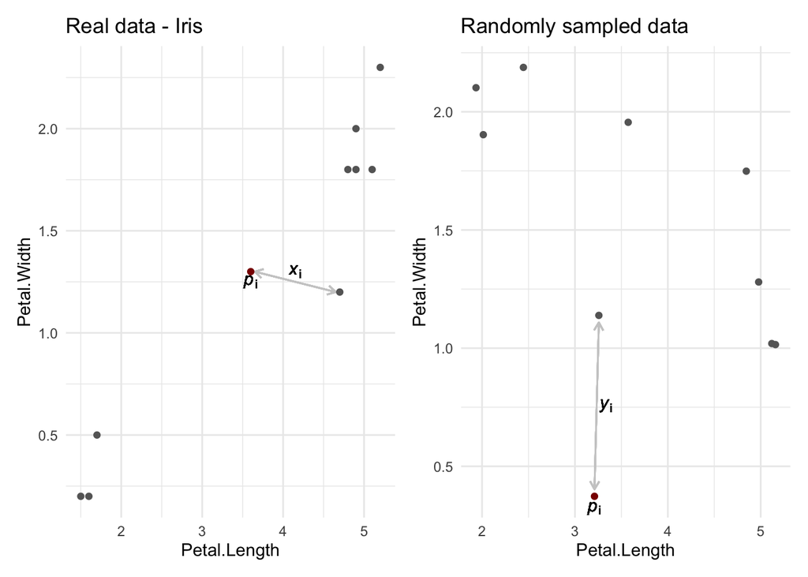

```r
set.seed(42)
tmp = iris[,3:4] %>%
    slice_sample(n=10) %>%
    mutate(color=0)
tmp$color[2] = 1
p1 = ggplot(tmp) +
    geom_segment(x=tmp[,1][2] + 0.05, y=tmp[,2][2], xend=tmp[,1][3] - 0.05, yend=tmp[,2][3],
                 arrow=arrow(length=unit(0.2, 'cm'), ends='both'), color="grey80") +
    geom_text(x=mean(tmp[2:3,1]), y=mean(tmp[2:3,2]) + 0.05,
              label=deparse(bquote(italic(x)[i])), parse=T) +
    geom_text(x=tmp[2,1], y=tmp[,2][2] - 0.05,
              label=deparse(bquote(italic(p)[i])), parse=T) +
    geom_point(aes(x=Petal.Length, y=Petal.Width, color=factor(color))) +
    scale_color_manual(values=c('grey40', 'darkred'), guide='none') +
    ggtitle('Real data - Iris') +
    theme_minimal()
tmp2 = data.frame(Petal.Length=runif(n=10, min=min(tmp[,1]), max=max(tmp[,1])),
                  Petal.Width=runif(n=10, min=min(tmp[,2]), max=max(tmp[,2])),
                  color=0)
tmp2$color[2] = 1
p2 = ggplot(tmp2) +
    geom_segment(x=tmp2[2,1], y=tmp2[2,2] + 0.03, xend=tmp2[6,1], yend=tmp2[6,2] - 0.03,
                 arrow=arrow(length=unit(0.2, 'cm'), ends='both'), color="grey80") +
    geom_text(x=mean(tmp2[c(2,6),1]) + 0.1, y=mean(tmp2[c(2,6),2]),
              label=deparse(bquote(italic(y)[i])), parse=T) +
    geom_text(x=tmp2[2,1], y=tmp2[,2][2] - 0.05,
              label=deparse(bquote(italic(p)[i])), parse=T) +
    geom_point(aes(x=Petal.Length, y=Petal.Width, color=factor(color))) +
    scale_color_manual(values=c('grey40', 'darkred'), guide='none') +
    ggtitle('Randomly sampled data') +
    theme_minimal()
p1 + p2
```

# 2 Random forest Hopkins statistic

```r
Hopkins.rf = function(x, k=1, prop=0.2, seed=42, ntree=1000) {
    if(!is.null(seed)) set.seed(seed)
    x_true = x %>%
        slice_sample(prop=prop)
    n = nrow(x_true)
    d = ncol(x_true)
    rf = randomForest(x=x_true,
                      proximity=T,
                      keep.forest=F,
                      ntree=ntree)
    prox = rf$proximity
    diag(prox) = -1
    x_i = (1 - apply(prox, 1, function(.x) sort(.x, partial=(n - k + 1))[(n - k + 1)]))^d

    x_fake = x %>%
        mutate(across(everything(), ~ sample(.x, size=nrow(x)))) %>%
        slice_sample(prop=prop)
    rf = randomForest(x=x_fake,
                      proximity=T,
                      keep.forest=F,
                      ntree=ntree)
    prox = rf$proximity
    diag(prox) = -1
    y_i = (1 - apply(prox, 1, function(.x) sort(.x, partial=(n - k + 1))[(n - k + 1)]))^d

    sum(y_i) / (sum(x_i) + sum(y_i))
}
```

```r
Hopkins.rf2 = function(x, k=1, prop=0.2, seed=42, ntree=1000) {
    if(!is.null(seed)) set.seed(seed)
    x_true = x %>%
        slice_sample(prop=prop)
    n = nrow(x_true)
    d = ncol(x_true)
    rf = randomForest(x=x_true,
                      proximity=T,
                      keep.forest=F,
                      ntree=ntree)
    prox = rf$proximity
    diag(prox) = -1
    x_i = (1 - apply(prox, 1, function(.x) sort(.x, partial=(n - k + 1))[(n - k + 1)]))

    x_fake = x %>%
        mutate(across(everything(), ~ sample(.x, size=nrow(x)))) %>%
        slice_sample(prop=prop)
    rf = randomForest(x=x_fake,
                      proximity=T,
                      keep.forest=F,
                      ntree=ntree)
    prox = rf$proximity
    diag(prox) = -1
    y_i = (1 - apply(prox, 1, function(.x) sort(.x, partial=(n - k + 1))[(n - k + 1)]))

    list(y_i=y_i, x_i=x_i)
}
```

# 3 Tests on iris

Comparison to the `Hopkins` package

```r
tmp = iris[, 1:4] %>% scale()
vals = cache_rds({
    sapply(1:200, function(s) {
        c(Hopkins.rf(iris[,1:4], k=1, prop=0.2, seed=s),
          hopkins::hopkins(tmp, m=ceiling(0.2*nrow(iris)), k=1))
    })
}, rerun=F, clean=T)
vals = setNames(data.frame(t(vals)), c('hopkins.rf', 'hopkins')) %>%
    pivot_longer(everything())
```

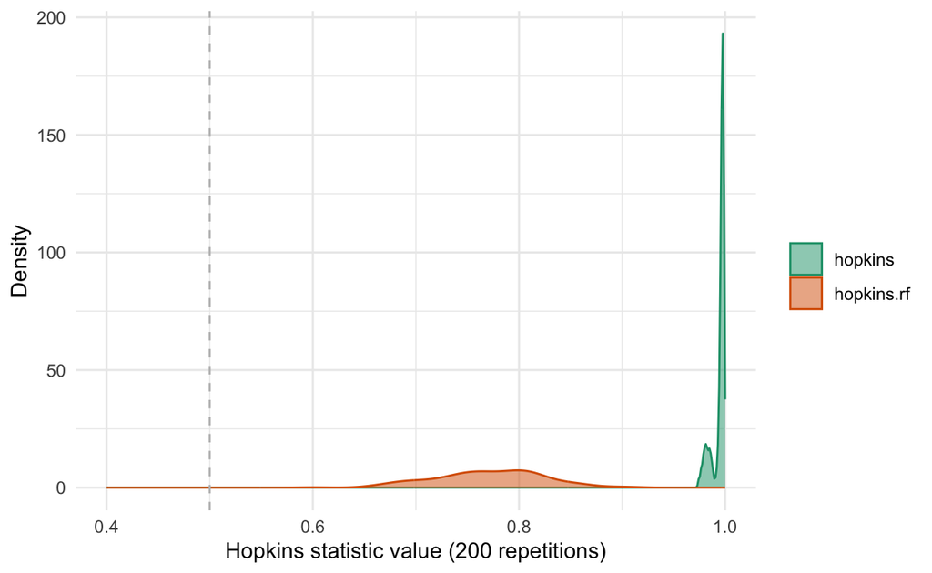

```r
ggplot(vals) +
    geom_density(aes(x=value, color=name, fill=name), alpha=0.5) +
    scale_color_brewer(name="", palette='Dark2') +
    scale_fill_brewer(name="", palette='Dark2') +
    ylab('Density') +
    scale_x_continuous(name="Hopkins statistic value (200 repetitions)", limits=c(0.4, 1)) +
    geom_vline(xintercept=0.5, linetype='dashed', color="grey") +
    theme_minimal()
```

Observations:

- The `Hopkins.rf` statistic is always greater than 0.5, suggesting that there is more clustering than at random
- However, the values are much smaller than those given by the `hopkins` package, indicating that we cannot use the same metric as used to measure the `hopkins` statistic calculated via euclidean distance

# 4 Testing the Beta(m, m) distribution

The `hopkins` package in CRAN states

> Under null hypothesis of spatial randomness, Hopkins statistic has a Beta(m,m) distribution, where ’m’ is the number of events/points sampled. This function calculates the p-value for the statistic.

This sections tests if this is true for randomly generated data of either continuous or discrete data using the Hopkins statistic code generated here.

## 4.1 Varying m

Here, we vary $m$, the number of points sampled for the statistic on completely randomized data (with constant $d=4$ dimensions). We expect the value of the rf Hopkins statistic to be centered around 0.5.

```r
betavals1 = cache_rds({
    sapply(1:200, function(s) {
        set.seed(s)
        iris_fake = iris[,1:4] %>%
            mutate(across(everything(), ~ sample(.x, size=nrow(iris))))
        c(
            p01 = Hopkins.rf(iris_fake, seed=s, prop=0.1), # m = 150 * 0.2 = 15
            p02 = Hopkins.rf(iris_fake, seed=s, prop=0.2), # m = 150 * 0.2 = 30
            p03 = Hopkins.rf(iris_fake, seed=s, prop=0.3), # m = 150 * 0.3 = 45
            p04 = Hopkins.rf(iris_fake, seed=s, prop=0.4), # m = 150 * 0.4 = 60
            p05 = Hopkins.rf(iris_fake, seed=s, prop=0.5) # m = 150 * 0.4 = 75
        )
    })
}, rerun=F, clean=T)
vals = data.frame(t(betavals1)) %>%
    pivot_longer(everything()) %>%
    mutate(name = case_match(name,
               'p01' ~ '15',
               'p02' ~ '30',
               'p03' ~ '45',
               'p04' ~ '60',
               'p05' ~ '75'))
```

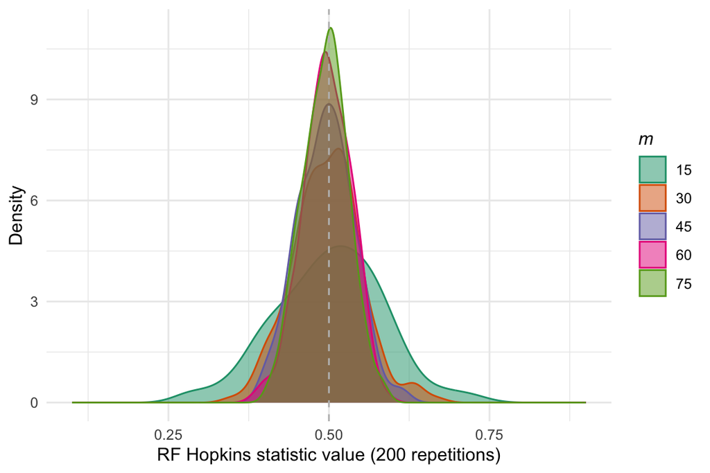

```r
ggplot(vals) +
    geom_density(aes(x=value, color=name, fill=name), alpha=0.5) +
    scale_color_brewer(name=bquote(italic(m)), palette='Dark2') +
    scale_fill_brewer(name=bquote(italic(m)), palette='Dark2') +
    ylab('Density') +
    scale_x_continuous(name="RF Hopkins statistic value (200 repetitions)", limits=c(0.1, 0.9)) +
    geom_vline(xintercept=0.5, linetype='dashed', color="grey") +
    theme_minimal()
```

Observations:

- It still seems that smaller values of $m$ produce a wider tail.
- The rf Hopkins statistic appears to still follow a symmetric bell curve distribution, which suggests that the Beta distribution is a good fit (with shape 1 = shape 2)
- The parameterization of the Beta distribution using rf Hopkins and traditional Hopkins may be different.

```r
qqplot1 = function(expected, observed, title="") {
    lim = range(c(expected, observed))
    ggplot() +
        geom_point(aes(x=expected, y=observed)) +
        geom_abline(slope=1, intercept=0, linetype='dashed', color="grey") +
        theme_minimal() +
        ggtitle(title) +
        coord_fixed() +
        xlim(lim) +
        ylim(lim)
}
qqplot2 = function(expected, observed, title="") {
    observed = observed - expected
    lim = max(abs(observed))
    lim = c(-lim, lim)
    ggplot() +
        geom_point(aes(x=expected, y=observed)) +
        geom_abline(slope=1, intercept=0, linetype='dashed', color="grey") +
        theme_minimal() +
        ggtitle(title) +
        geom_hline(yintercept=0, linetype='dashed', color="grey") +
        ylim(lim) +
        ylab("Residuals")
}
```

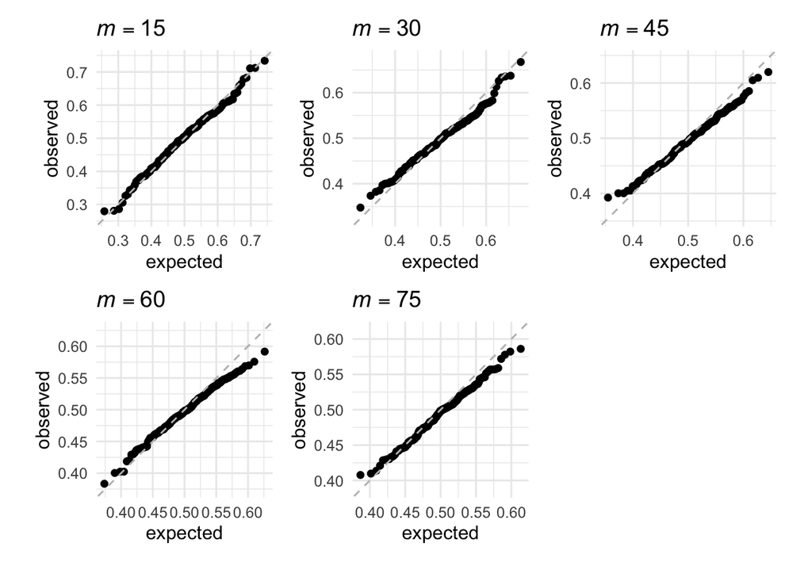

```r
# qbeta(p, 15, 15)
p = ((1:200)/200 - 1/400)
mvals = c(15, 30, 45, 60, 75)
plots = lapply(seq_along(mvals), function(i) {
    qqplot1(
        observed=sort(betavals1[i,]),
        expected=qbeta(p, mvals[i], mvals[i]),
        title=bquote(italic(m) == .(mvals[i]))
    )
})
wrap_plots(plots, ncol=3)
```

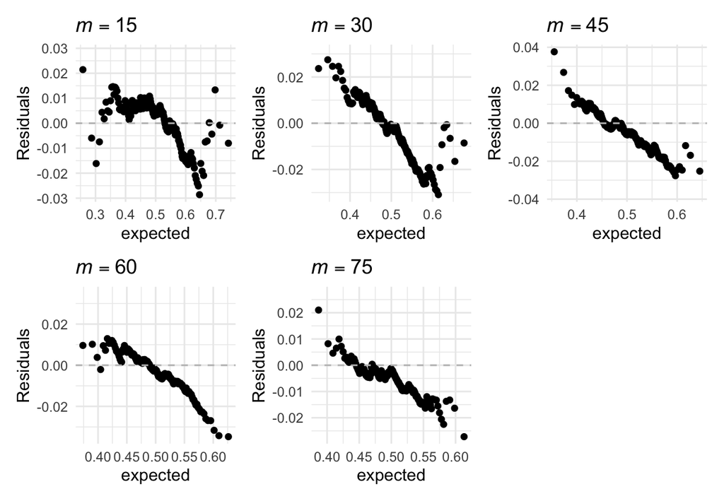

```r
plots = lapply(seq_along(mvals), function(i) {
    qqplot2(
        observed=sort(betavals1[i,]),
        expected=qbeta(p, mvals[i], mvals[i]),
        title=bquote(italic(m) == .(mvals[i]))
    )
})
wrap_plots(plots, ncol=3)
```

Plotting the QQ plots against the parameterization in the `hopkins` package suggests that the Beta(m, m) distribution does not fit well for the rf Hopkins statistic. It is close, but there is a slight consistent overestimate at the lower tail, and underestimate at the upper tail.

I can estimate the empirical parameters of the Beta distribution using the maximum likelihood estimator. It is conveniently implemented in the `EnvStats` package.

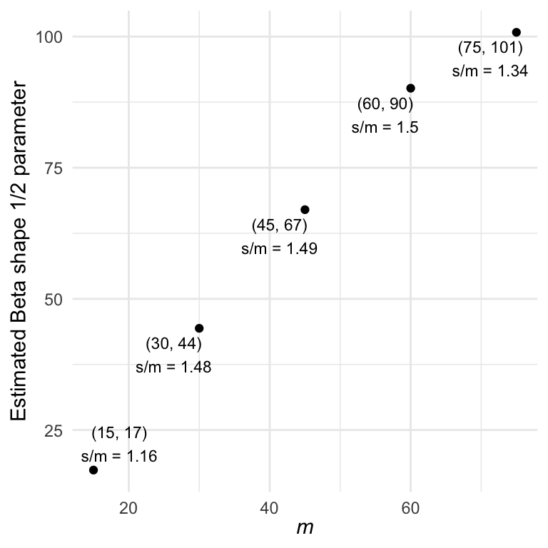

```r
tmp = data.frame(t(sapply(1:nrow(betavals1), function(i) {
    EnvStats::ebeta(betavals1[i,], method='mle')$parameters
})))
tmp$mvals = mvals
tmp$est_shape = (tmp$shape1 + tmp$shape2) / 2

ggplot(tmp) +
    aes(x=mvals, y=est_shape) +
    geom_point() +
    ggrepel::geom_text_repel(aes(label=paste0('(', mvals, ', ', round(est_shape), ')',
                                              '\ns/m = ', round(est_shape/mvals, 2))),
                             size=3) +
    xlab(bquote(italic(m))) +
    ylab("Estimated Beta shape 1/2 parameter") +
    theme_minimal()
```

The rf Hopkins statistic appears to approximately follow a $Beta(1.5m, 1.5m)$ distribution. This varies a bit at $m=15$ and $m=75$. I would likely need more samples to confirm this.

## 4.2 Varying d

The `hopkins` package in CRAN further states that

> The distribution of Hopkins statistic is Beta(m,m), independent of the dimensionality of the data d.

I test this claim for the rf Hopkins statistic here by varying $d$ while keeping $m$ constant at 30.

```r
dvals = c(4, 5, 10, 15, 20, 100)
betavals2 = cache_rds({
    sapply(1:200, function(s) {
        sapply(dvals, function(d) {
            set.seed(s)
            tmp = do.call("data.frame", lapply(1:d, function(.x) runif(n=30)))
            Hopkins.rf(tmp, seed=s, prop=1)
        })
    })
}, rerun=F, clean=T)
vals = setNames(data.frame(t(betavals2)), as.character(dvals)) %>%
    pivot_longer(everything()) %>%
    mutate(name=factor(name, levels=dvals))
```

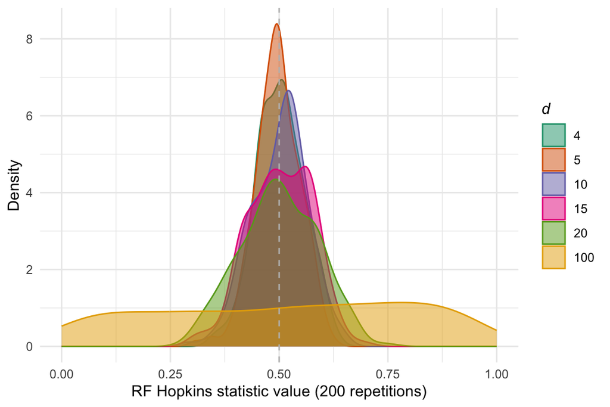

```r
ggplot(vals) +
    geom_density(aes(x=value, color=name, fill=name), alpha=0.5) +
    scale_color_brewer(name=bquote(italic(d)), palette='Dark2') +
    scale_fill_brewer(name=bquote(italic(d)), palette='Dark2') +
    ylab('Density') +
    scale_x_continuous(name="RF Hopkins statistic value (200 repetitions)", limits=c(0, 1)) +
    geom_vline(xintercept=0.5, linetype='dashed', color="grey") +
    theme_minimal()
```

The plot above strongly suggests that the rf Hopkins statistic is dependent on the number of dimensions $d$.

```r
betavals3 = cache_rds({
    lapply(dvals, function(d) {
        lapply(1:200, function(s) {
            set.seed(s)
            tmp = do.call("data.frame", lapply(1:d, function(.x) runif(n=30)))
            Hopkins.rf2(tmp, seed=s, prop=1)
        })
    })
}, rerun=F, clean=T)
```

It may be that taking the distance to the power of $d$ is too extreme when using rf Hopkins. I can test if a smaller power (e.g., $x_{i}^{d/2}$) yeilds a better distribution.

Here, I iterate over possible powers for the distance using rf Hopkins, and find the best power given a true dimensionality for a data set (using the $Beta(m, m)$ distribution as a target distribution).

```r
hopcalc = function(obj, d=1) {
    y_i = obj$y_i^d
    x_i = obj$x_i^d
    sum(y_i) / (sum(x_i) + sum(y_i))
}
target_dist = qbeta(p, shape1=30, shape2=30)
comp_dists = function(x, x_target) {
    sum(abs(x - x_target))
}
test_d = function(i, print.out=T) {
    d = dvals[i]
    if(d < 50) {
        power = seq(d/2, d*2, length.out=20)
    } else {
        power = seq(10, d/2, length.out=50)
    }
    tmp = sapply(power, function(dt) {
        tmp = sapply(1:200, function(s) hopcalc(betavals3[[i]][[s]], dt))
        comp_dists(sort(tmp), target_dist)
    })
    if(print.out) {
        return(rbind(sum_diff=tmp, power=power, true_d=d))
    }
    power[which.min(tmp)]
}

dbest = sapply(1:6, test_d, print.out=F)
tmp = data.frame(actual_dimensionality=dvals, best_power=dbest)
tmp
```

| actual_dimensionality | best_power |
| --- | --- |
| 4 | 4.842 |
| 5 | 6.447 |
| 10 | 9.737 |
| 15 | 12.237 |
| 20 | 13.158 |
| 100 | 22.245 |

The points look like there’s a logarithmic relationship between the actual dimensionality and the best power.

```r
logEstimate = lm(best_power ~ log(actual_dimensionality), data=tmp)
summary(logEstimate)
```

```
##
## Call:
## lm(formula = best_power ~ log(actual_dimensionality), data = tmp)
##
## Residuals:
##      1      2      3      4      5      6
## -0.125  0.291 -0.115  0.223 -0.390  0.116
##
## Coefficients:
##                            Estimate Std. Error t value Pr(>|t|)
## (Intercept)                   -2.42       0.31   -7.81   0.0014 **
## log(actual_dimensionality)     5.33       0.11   48.26  1.1e-06 ***
## ---
## Signif. codes:  0 '***' 0.001 '**' 0.01 '*' 0.05 '.' 0.1 ' ' 1
##
## Residual standard error: 0.287 on 4 degrees of freedom
## Multiple R-squared:  0.998,  Adjusted R-squared:  0.998
## F-statistic: 2.33e+03 on 1 and 4 DF,  p-value: 1.1e-06
```

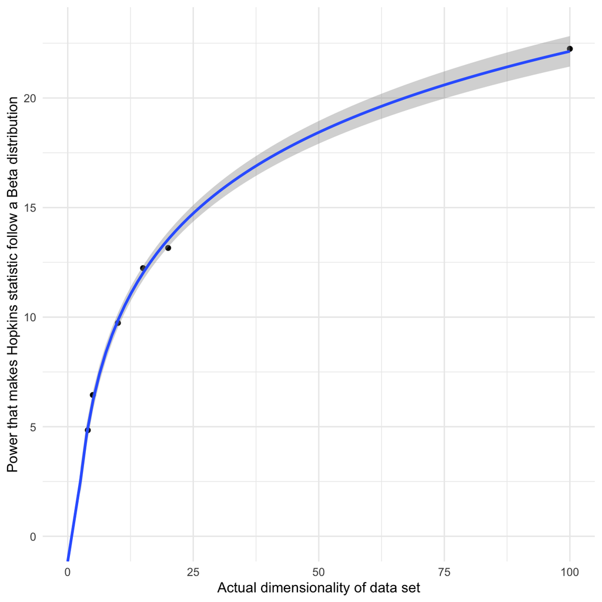

```r
ggplot(tmp) +
    aes(x=actual_dimensionality, y=best_power) +
    geom_point() +
    stat_smooth(method='lm', formula=y~ log(x), fullrange=TRUE) +
    xlab("Actual dimensionality of data set") +
    ylab("Power that makes Hopkins statistic follow a Beta distribution") +
    xlim(0, 100) +
    ylim(0, 23) +
    theme_minimal()
```

The very high R squared suggests that the logarithmic model is a good fit.

This would suggest that a better formulation of the Hopkins statistic using random forest distance might be given by:

**Unknown power H**

$$H = \frac{\sum_{i=1}^n y_{i}^{?}}{\sum_{i=1}^n y_{i}^{?} + \sum_{i=1}^n
x_{i}^{?}}$$

$$\begin{equation}
H_\textrm{rf} = \frac{\sum_{i=1}^n y_{i}^{5.332\log{d} - 2.425}}
{\sum_{i=1}^n y_{i}^{5.332\log{d} - 2.425} + \sum_{i=1}^n
x_{i}^{5.332\log{d} - 2.425}}.
\end{equation}$$

This is only empirical shown, and does not take into context if there’s a further effect depending on $m$ or $ntree$.

This may also suggest that the reason why the Beta distribution was slightly off in section 4.1 is the bias in $d$.

## 4.3 Varying m with new formulation

Given the results of the previous two sections. I want to test if the new formulation generated in section 4.2 works across values of $m$ (equation 1).

```r
Hopkins.rf3 = function(x, k=1, prop=0.2, seed=42, ntree=1000) {
    if(!is.null(seed)) set.seed(seed)
    x_true = x %>%
        slice_sample(prop=prop)
    n = nrow(x_true)
    d = 5.332*log(ncol(x_true)) - 2.425
    rf = randomForest(x=x_true,
                      proximity=T,
                      keep.forest=F,
                      ntree=ntree)
    prox = rf$proximity
    diag(prox) = -1
    x_i = (1 - apply(prox, 1, function(.x) sort(.x, partial=(n - k + 1))[(n - k + 1)]))^d

    x_fake = x %>%
        mutate(across(everything(), ~ sample(.x, size=nrow(x)))) %>%
        slice_sample(prop=prop)
    rf = randomForest(x=x_fake,
                      proximity=T,
                      keep.forest=F,
                      ntree=ntree)
    prox = rf$proximity
    diag(prox) = -1
    y_i = (1 - apply(prox, 1, function(.x) sort(.x, partial=(n - k + 1))[(n - k + 1)]))^d

    sum(y_i) / (sum(x_i) + sum(y_i))
}
```

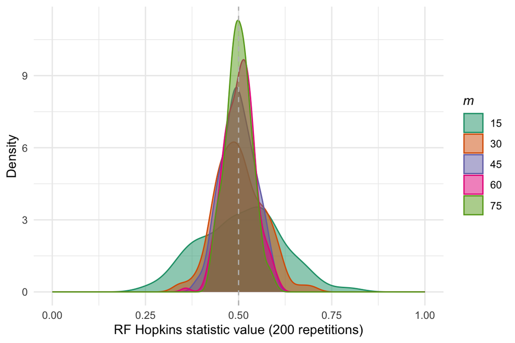

```r
betavals4 = cache_rds({
    sapply(1:200, function(s) {
        set.seed(s)
        tmp = do.call("data.frame", lapply(1:10, function(.x) runif(n=75)))
        c(
            m15 = Hopkins.rf3(tmp, seed=s, prop=0.2), # m = 75 * 0.2 = 15
            m30 = Hopkins.rf3(tmp, seed=s, prop=0.4), # m = 75 * 0.2 = 30
            m45 = Hopkins.rf3(tmp, seed=s, prop=0.6), # m = 75 * 0.3 = 45
            m60 = Hopkins.rf3(tmp, seed=s, prop=0.8), # m = 75 * 0.4 = 60
            m75 = Hopkins.rf3(tmp, seed=s, prop=1.0) # m = 75 * 0.4 = 75
        )
    })
}, rerun=F, clean=T)
vals = data.frame(t(betavals4)) %>%
    pivot_longer(everything()) %>%
    mutate(name=gsub('m', '', name))
ggplot(vals) +
    geom_density(aes(x=value, color=name, fill=name), alpha=0.5) +
    scale_color_brewer(name=bquote(italic(m)), palette='Dark2') +
    scale_fill_brewer(name=bquote(italic(m)), palette='Dark2') +
    ylab('Density') +
    scale_x_continuous(name="RF Hopkins statistic value (200 repetitions)", limits=c(0, 1)) +
    geom_vline(xintercept=0.5, linetype='dashed', color="grey") +
    theme_minimal()
```

This distributions across values of $m$ is as expected, with higher values of $m$ having smaller tails.

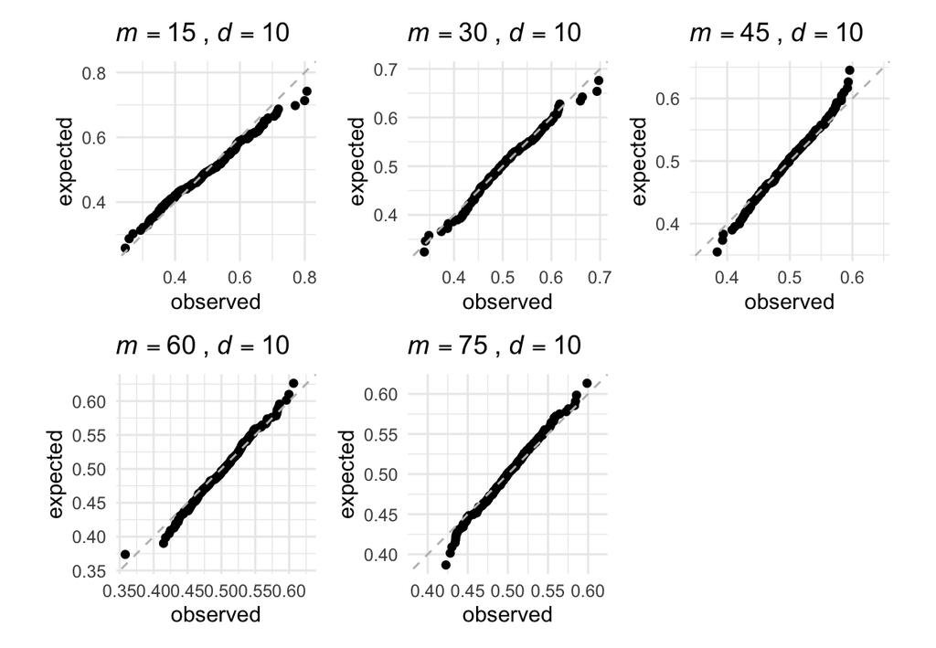

```r
p = ((1:200)/200 - 1/400)
mvals = c(15, 30, 45, 60, 75)
plots = lapply(seq_along(mvals), function(i) {
    betavals4 = data.frame(
        observed=sort(betavals4[i,]),
        expected=qbeta(p, mvals[i], mvals[i]))
    lim = range(c(betavals4$observed, betavals4$expected))
    ggplot(betavals4) +
        geom_point(aes(x=observed, y=expected)) +
        geom_abline(slope=1, intercept=0, linetype='dashed', color="grey") +
        theme_minimal() +
        ggtitle(bquote(italic(m) == .(mvals[i]) ~ ',' ~ italic(d) == .(10))) +
        coord_fixed() +
        xlim(lim) +
        ylim(lim)
})
wrap_plots(plots, ncol=3)
```

The dispersion appears to be underestimated (very) slightly at lower values of $m$, and overestimated at higher values of $m$. We can see that the tails appear most even at $m=30$. Given that we calculated values for the reformulation while fixing $m = 30$ in section 4.2, this might be expected. The differences in the distribution are very slight.

**same results with d=4**

```r
betavals5 = cache_rds({
    sapply(1:200, function(s) {
        set.seed(s)
        tmp = do.call("data.frame", lapply(1:4, function(.x) runif(n=75)))
        c(
            m15 = Hopkins.rf3(tmp, seed=s, prop=0.2), # m = 75 * 0.2 = 15
            m30 = Hopkins.rf3(tmp, seed=s, prop=0.4), # m = 75 * 0.2 = 30
            m45 = Hopkins.rf3(tmp, seed=s, prop=0.6), # m = 75 * 0.3 = 45
            m60 = Hopkins.rf3(tmp, seed=s, prop=0.8), # m = 75 * 0.4 = 60
            m75 = Hopkins.rf3(tmp, seed=s, prop=1.0) # m = 75 * 0.4 = 75
        )
    })
}, rerun=F, clean=T)
```

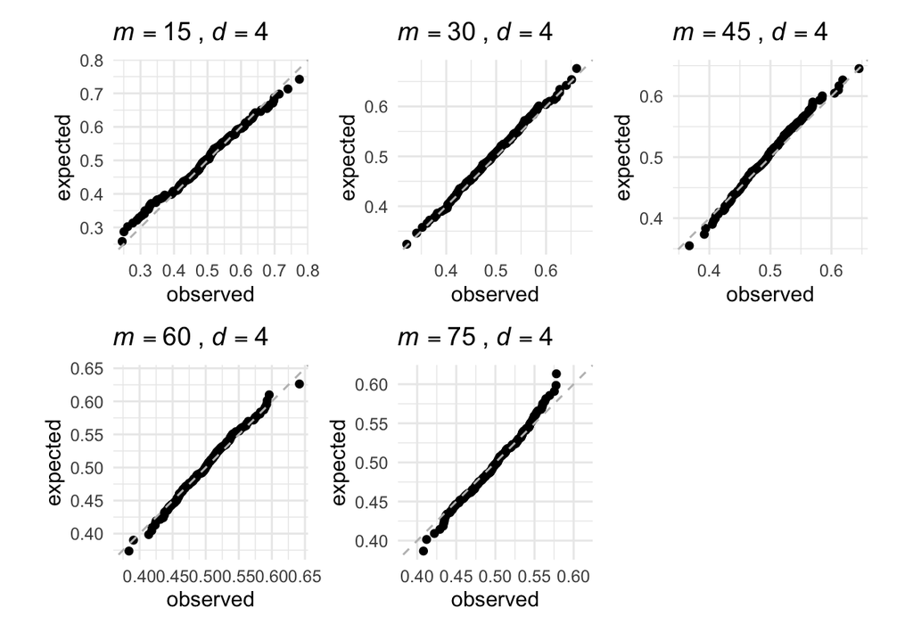

```r
mvals = c(15, 30, 45, 60, 75)
plots = lapply(seq_along(mvals), function(i) {
    betavals5 = data.frame(
        observed=sort(betavals5[i,]),
        expected=qbeta(p, mvals[i], mvals[i]))
    lim = range(c(betavals5$observed, betavals5$expected))
    ggplot(betavals5) +
        geom_point(aes(x=observed, y=expected)) +
        geom_abline(slope=1, intercept=0, linetype='dashed', color="grey") +
        theme_minimal() +
        ggtitle(bquote(italic(m) == .(mvals[i]) ~ ',' ~ italic(d) == 4)) +
        coord_fixed() +
        xlim(lim) +
        ylim(lim)
})
wrap_plots(plots, ncol=3)
```

## 4.4 Full parameter sweep over d and m

Because it appears that the null distribution of $H_{rf}$ is dependent on both $d$ and $m$, I conduct a full parameter sweep over values of $d$ and $m$.

```r
dvals = c(5, 10, 20, 50, 100, 200)
mvals = c(5, 10, 20, 50, 100, 200)

betavals6 = cache_rds({
    lapply(dvals, function(d) {
        ic(d, " out of ", dvals, "\n")
        set.seed(42)
        tmp = do.call("data.frame", lapply(1:d, function(.x) runif(n=max(mvals))))
        lapply(mvals, function(m) {
            lapply(1:200, function(s) {
                set.seed(s)
                Hopkins.rf2(tmp, seed=s, prop=m/max(mvals))
            })
        })
    })
}, rerun=F, clean=T)
```

**beta test6 collectdata**

```r
test_power = function(i, j, print.out=T) {
    d = dvals[i]
    m = mvals[j]
    test_powers = (log(d)*seq(2, 10, length.out=100)) - 2.425
    target_dist = qbeta(p, shape1=m, shape2=m)
    tmp = sapply(test_powers, function(dt) {
        tmp = sapply(1:200, function(s) hopcalc(betavals6[[i]][[j]][[s]], dt))
        comp_dists(sort(tmp), target_dist)
    })
    if(print.out) {
        return(rbind(sum_diff=tmp, power=test_powers, true_d=d))
    }
    data.frame(d=d, m=m, best_power=test_powers[which.min(tmp)])
}
tmp = cache_rds({
    bind_rows(lapply(1:6, function(i)
                     bind_rows(lapply(1:6, function(j) test_power(i, j, print.out=F)))))
}, rerun=T, clean=T)
tmp
```

| d | m | best_power |
| --- | --- | --- |
| 5 | 5 | 2.745 |
| 5 | 10 | 4.045 |
| 5 | 20 | 5.346 |
| 5 | 50 | 5.996 |
| 5 | 100 | 6.776 |
| 5 | 200 | 7.817 |
| 10 | 5 | 4.041 |
| 10 | 10 | 6.832 |
| 10 | 20 | 7.948 |
| 10 | 50 | 10.181 |
| 10 | 100 | 13.344 |
| 10 | 200 | 19.671 |
| 20 | 5 | 4.535 |
| 20 | 10 | 7.924 |
| 20 | 20 | 11.071 |
| 20 | 50 | 17.365 |
| 20 | 100 | 17.365 |
| 20 | 200 | 22.207 |
| 50 | 5 | 6.663 |
| 50 | 10 | 10.141 |
| 50 | 20 | 15.515 |
| 50 | 50 | 21.521 |
| 50 | 100 | 32.270 |
| 50 | 200 | 36.695 |
| 100 | 5 | 6.785 |
| 100 | 10 | 11.623 |
| 100 | 20 | 16.461 |
| 100 | 50 | 26.509 |
| 100 | 100 | 35.812 |
| 100 | 200 | 43.627 |
| 200 | 5 | 8.172 |
| 200 | 10 | 12.453 |
| 200 | 20 | 16.735 |
| 200 | 50 | 26.154 |
| 200 | 100 | 44.564 |
| 200 | 200 | 50.558 |

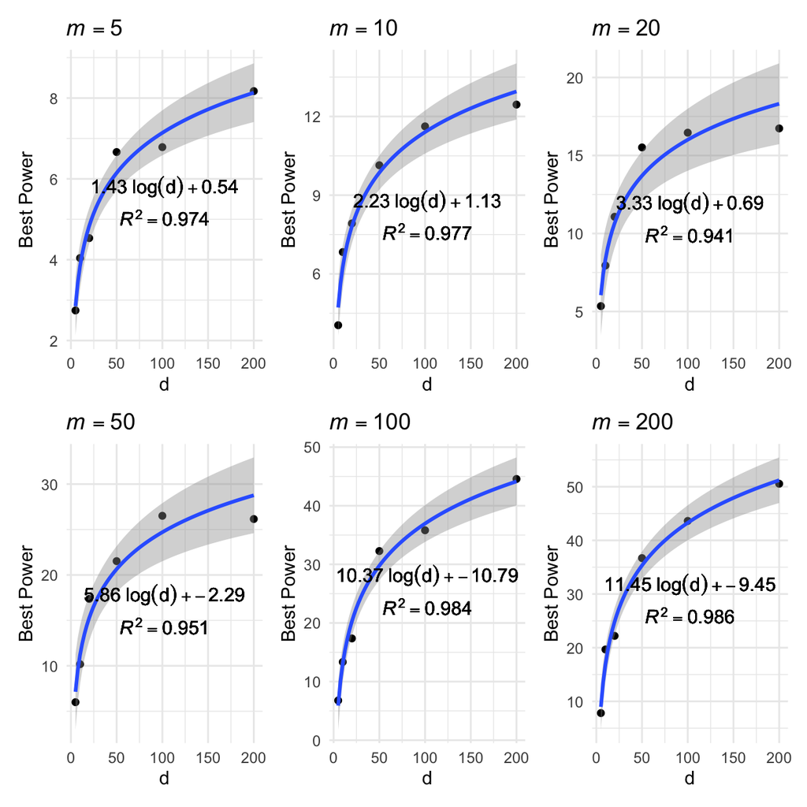

```r
logfit = function(dat, title="") {
    logEstimate = lm(best_power ~ log(d), data=dat)
    ggplot(dat) +
        aes(x=d, y=best_power) +
        geom_point() +
        stat_smooth(method='lm', formula=y~log(x), fullrange=TRUE) +
        geom_text(x=mean(range(dat$d)), y=mean(range(dat$best_power)),
                  label=deparse(bquote(atop(
                      .(round(coef(logEstimate)[[2]], 2))~log(d) + .(round(coef(logEstimate)[[1]], 2)),
                      italic(R)^2 == .(round(summary(logEstimate)$r.squared, 3))
                  ))), parse=T) +
        ggtitle(title) +
        xlab("d") +
        ylab("Best Power") +
        theme_minimal()
}
plots = lapply(mvals, function(m) logfit(tmp[tmp$m==m,], bquote(italic(m) == .(m))))

wrap_plots(plots, ncol=3, axis_titles="collect")
```

**print logfits**

```r
logfit2 = function(dat) {
    logEstimate = lm(best_power ~ log(d), data=dat)
    list(summary(logEstimate), confint(logEstimate))
}
lapply(mvals, function(m) logfit2(tmp[tmp$m==m,]))
```

```
## [[1]]
## [[1]][[1]]
##
## Call:
## lm(formula = best_power ~ log(d), data = dat)
##
## Residuals:
##       1       7      13      19      25      31
## -0.1034  0.1998 -0.2991  0.5171 -0.3539  0.0395
##
## Coefficients:
##             Estimate Std. Error t value Pr(>|t|)
## (Intercept)    0.543      0.429    1.27  0.27407
## log(d)         1.432      0.116   12.32  0.00025 ***
## ---
## Signif. codes:  0 '***' 0.001 '**' 0.01 '*' 0.05 '.' 0.1 ' ' 1
##
## Residual standard error: 0.365 on 4 degrees of freedom
## Multiple R-squared:  0.974,  Adjusted R-squared:  0.968
## F-statistic:  152 on 1 and 4 DF,  p-value: 0.00025
##
##
## [[1]][[2]]
##               2.5 % 97.5 %
## (Intercept) -0.6471  1.733
## log(d)       1.1095  1.755
##
##
## [[2]]
## [[2]][[1]]
##
## Call:
## lm(formula = best_power ~ log(d), data = dat)
##
## Residuals:
##      2      8     14     20     26     32
## -0.674  0.565  0.110  0.282  0.217 -0.500
##
## Coefficients:
##             Estimate Std. Error t value Pr(>|t|)
```

[output cut: 111 more lines]

```
##             Estimate Std. Error t value Pr(>|t|)
## (Intercept)   -9.447      2.509   -3.76     0.02 *
## log(d)        11.449      0.681   16.81  7.3e-05 ***
## ---
## Signif. codes:  0 '***' 0.001 '**' 0.01 '*' 0.05 '.' 0.1 ' ' 1
##
## Residual standard error: 2.14 on 4 degrees of freedom
## Multiple R-squared:  0.986,  Adjusted R-squared:  0.983
## F-statistic:  283 on 1 and 4 DF,  p-value: 7.34e-05
##
##
## [[6]][[2]]
##               2.5 % 97.5 %
## (Intercept) -16.414  -2.48
## log(d)        9.558  13.34
```

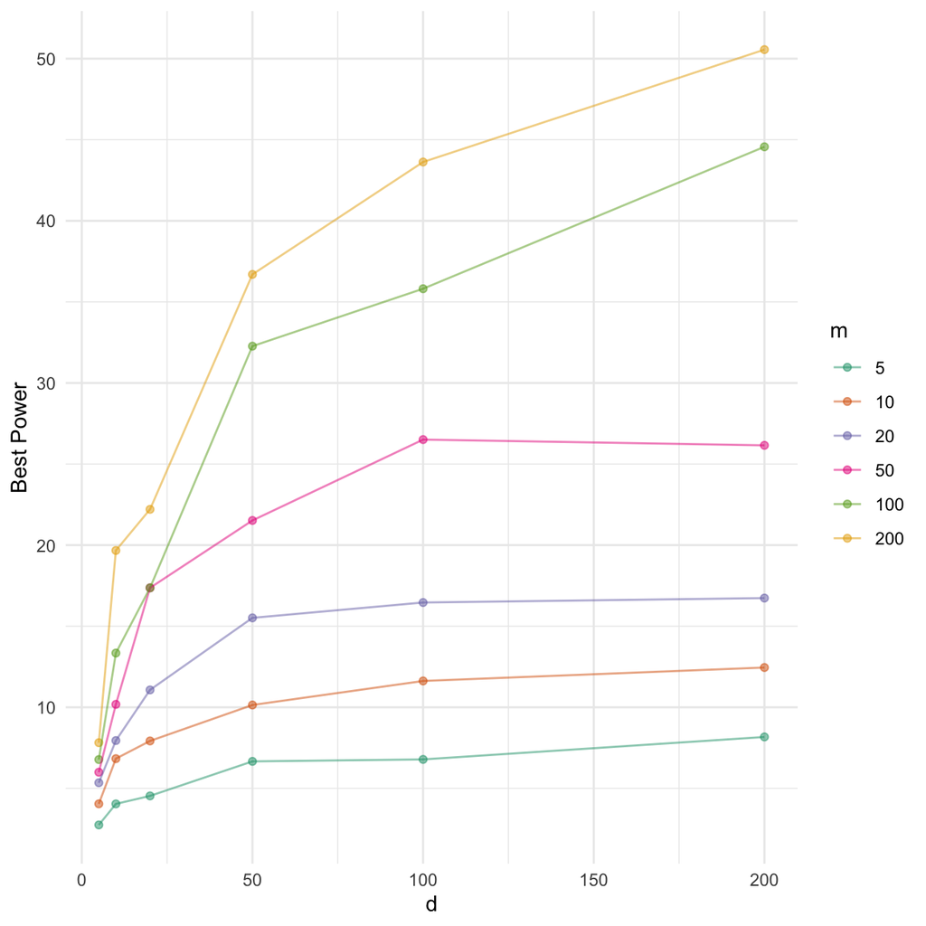

```r
ggplot(tmp) +
    geom_point(aes(x=d, y=best_power, color=factor(m)), alpha=0.5) +
    geom_line(aes(x=d, y=best_power, color=factor(m)), alpha=0.5) +
    scale_color_brewer(name="m", palette="Dark2") +
    xlab("d") +
    ylab("Best Power") +
    theme_minimal()
```

**lasso full param sweep**

```r
y = tmp$best_power
f <- as.formula(y ~ .*.)
x = tmp %>%
    select(d, m) %>%
    mutate(logm = log(m),
           logd = log(d),
           mtry = floor(sqrt(d)),
           sqrtd = sqrt(d),
           cbrtd = d^(1/3),
           sqrtm = sqrt(m),
           cbrtm = m^(1/3),
    )
x <- model.matrix(f, x)[, -1]

lasso = cv.glmnet(x, y, alpha=1, family='gaussian')
i = which(lasso$lambda == lasso$lambda.1se)
coef(lasso, s=lasso$lambda.1se, exact=T)
r2 = 1 - lasso$cvm[i]/var(y)
cat("r2 = ", round(r2, 3), "\n")
x = tmp %>%
    select(d, m, best_power) %>%
    mutate(logm = log(m),
           logd = log(d),
           mtry = floor(sqrt(d)),
           sqrtd = sqrt(d),
           cbrtd = d^(1/3),
           sqrtm = sqrt(m),
           cbrtm = m^(1/3)
    )
```

```
## 46 x 1 sparse Matrix of class "dgCMatrix"
##                   s1
## (Intercept) -0.03910
## d            .
## m            .
## logm         .
## logd         .
## mtry         .
## sqrtd        .
## cbrtd        .
## sqrtm        .
## cbrtm        .
## d:m          .
## d:logm       .
## d:logd       .
## d:mtry       .
## d:sqrtd      .
## d:cbrtd      .
## d:sqrtm      .
## d:cbrtm      .
## m:logm       .
## m:logd       .
## m:mtry       .
## m:sqrtd      .
## m:cbrtd      .
## m:sqrtm      .
## m:cbrtm      .
## logm:logd    0.37855
## logm:mtry    .
## logm:sqrtd   .
## logm:cbrtd   .
## logm:sqrtm   .
## logm:cbrtm   .
## logd:mtry    .
## logd:sqrtd   .
## logd:cbrtd   .
## logd:sqrtm   0.14955
## logd:cbrtm   0.59795
## mtry:sqrtd   .
## mtry:cbrtd   .
## mtry:sqrtm   0.03153
## mtry:cbrtm   .
## sqrtd:cbrtd  .
## sqrtd:sqrtm  .
## sqrtd:cbrtm  .
## cbrtd:sqrtm  .
## cbrtd:cbrtm  .
## sqrtm:cbrtm  .
## r2 =  0.926
```

**logm logd interaction only**

```r
lme = lm(y ~ logm:logd + 0, data=x)
summary(lme)
```

```
##
## Call:
## lm(formula = y ~ logm:logd + 0, data = x)
##
## Residuals:
##    Min     1Q Median     3Q    Max
##  -7.14  -3.68  -2.43  -1.00   8.34
##
## Coefficients:
##           Estimate Std. Error t value Pr(>|t|)
## logm:logd   1.5040     0.0506    29.7   <2e-16 ***
## ---
## Signif. codes:  0 '***' 0.001 '**' 0.01 '*' 0.05 '.' 0.1 ' ' 1
##
## Residual standard error: 4.12 on 35 degrees of freedom
## Multiple R-squared:  0.962,  Adjusted R-squared:  0.961
## F-statistic:  885 on 1 and 35 DF,  p-value: <2e-16
```

**cbrtm logd interaction only**

```r
lme = lm(y ~ cbrtm:logd + 0, data=x)
summary(lme)
#lme = lm(y ~ cbrtm:logd, data=x)
#summary(lme)
```

```
##
## Call:
## lm(formula = y ~ cbrtm:logd + 0, data = x)
##
## Residuals:
##    Min     1Q Median     3Q    Max
## -6.186 -3.176 -1.748 -0.193  7.975
##
## Coefficients:
##            Estimate Std. Error t value Pr(>|t|)
## cbrtm:logd   1.4878     0.0413      36   <2e-16 ***
## ---
## Signif. codes:  0 '***' 0.001 '**' 0.01 '*' 0.05 '.' 0.1 ' ' 1
##
## Residual standard error: 3.42 on 35 degrees of freedom
## Multiple R-squared:  0.974,  Adjusted R-squared:  0.973
## F-statistic: 1.3e+03 on 1 and 35 DF,  p-value: <2e-16
```

**cbrtm mtry interaction only**

```r
lme = lm(y ~ cbrtm:mtry + 0, data=x)
summary(lme)
lme = lm(y ~ cbrtm:mtry, data=x)
summary(lme)
```

```
##
## Call:
## lm(formula = y ~ cbrtm:mtry + 0, data = x)
##
## Residuals:
##    Min     1Q Median     3Q    Max
## -9.283 -0.526  1.191  3.681 10.025
##
## Coefficients:
##            Estimate Std. Error t value Pr(>|t|)
## cbrtm:mtry   0.6846     0.0274      25   <2e-16 ***
## ---
## Signif. codes:  0 '***' 0.001 '**' 0.01 '*' 0.05 '.' 0.1 ' ' 1
##
## Residual standard error: 4.87 on 35 degrees of freedom
## Multiple R-squared:  0.947,  Adjusted R-squared:  0.945
## F-statistic:  622 on 1 and 35 DF,  p-value: <2e-16
##
##
## Call:
## lm(formula = y ~ cbrtm:mtry, data = x)
##
## Residuals:
##    Min     1Q Median     3Q    Max
## -9.281 -2.057  0.145  2.680  9.728
##
## Coefficients:
##             Estimate Std. Error t value Pr(>|t|)
## (Intercept)   2.0627     1.2664    1.63     0.11
## cbrtm:mtry    0.6303     0.0428   14.72  2.6e-16 ***
## ---
## Signif. codes:  0 '***' 0.001 '**' 0.01 '*' 0.05 '.' 0.1 ' ' 1
##
## Residual standard error: 4.76 on 34 degrees of freedom
## Multiple R-squared:  0.864,  Adjusted R-squared:  0.86
## F-statistic:  217 on 1 and 34 DF,  p-value: 2.56e-16
```

Using only the interaction term and enforcing no intercept, we get a fit with adjusted $R^2$ of 0.961. The idea behind enforcing no intercept is because it makes the formula a bit simpler, and prevents negative powers.

**adjusted logm logd interaction**

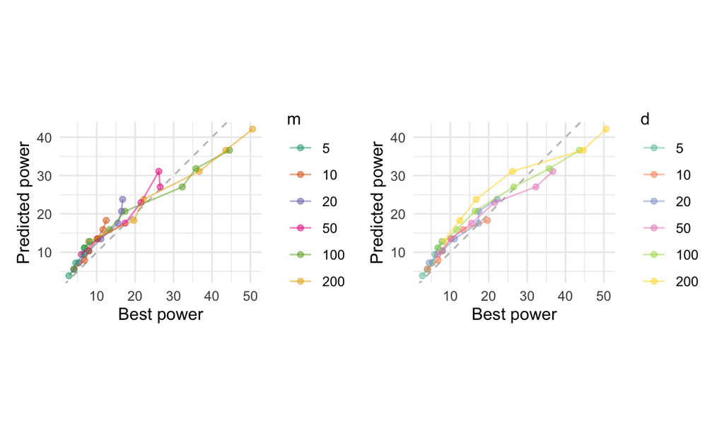

```r
tmp = x
tmp$pred = 1.5*tmp$logd*tmp$logm

p1 = ggplot(tmp) +
    geom_abline(slope=1, intercept=0, linetype='dashed', color="grey") +
    geom_point(aes(x=best_power, y=pred, color=factor(m)), alpha=0.5) +
    geom_line(aes(x=best_power, y=pred, color=factor(m)), alpha=0.5) +
    scale_color_brewer(name="m", palette="Dark2") +
    xlab("Best power") +
    ylab("Predicted power") +
    coord_fixed() +
    theme_minimal()
p2 = ggplot(tmp) +
    geom_abline(slope=1, intercept=0, linetype='dashed', color="grey") +
    geom_point(aes(x=best_power, y=pred, color=factor(d)), alpha=0.5) +
    geom_line(aes(x=best_power, y=pred, color=factor(d)), alpha=0.5) +
    scale_color_brewer(name="d", palette="Set2") +
    xlab("Best power") +
    ylab("Predicted power") +
    coord_fixed() +
    theme_minimal()
p1 + p2
```

**adjusted cube root m logd interaction**

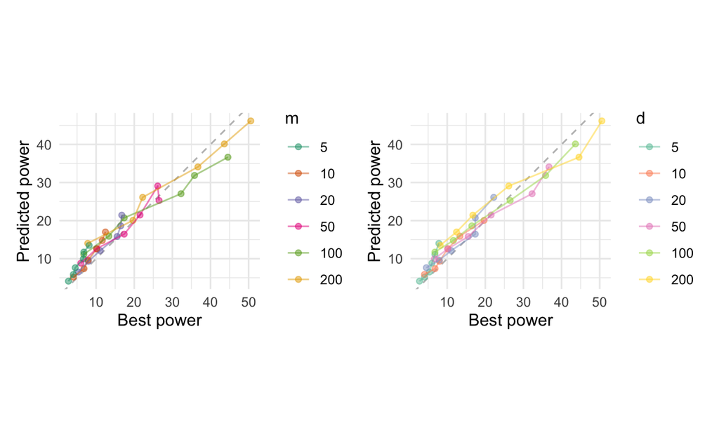

```r
tmp$pred = 1.49*tmp$cbrtm*tmp$logd

p1 = ggplot(tmp) +
    geom_abline(slope=1, intercept=0, linetype='dashed', color="grey") +
    geom_point(aes(x=best_power, y=pred, color=factor(m)), alpha=0.5) +
    geom_line(aes(x=best_power, y=pred, color=factor(m)), alpha=0.5) +
    scale_color_brewer(name="m", palette="Dark2") +
    xlab("Best power") +
    ylab("Predicted power") +
    coord_fixed() +
    theme_minimal()
p2 = ggplot(tmp) +
    geom_abline(slope=1, intercept=0, linetype='dashed', color="grey") +
    geom_point(aes(x=best_power, y=pred, color=factor(d)), alpha=0.5) +
    geom_line(aes(x=best_power, y=pred, color=factor(d)), alpha=0.5) +
    scale_color_brewer(name="d", palette="Set2") +
    xlab("Best power") +
    ylab("Predicted power") +
    coord_fixed() +
    theme_minimal()
p1 + p2
```

**adjusted cube root m square root d interaction**

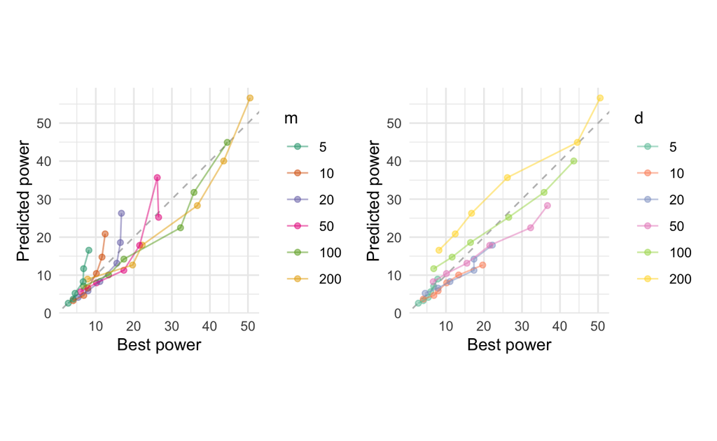

```r
tmp$pred = 0.6846*tmp$cbrtm*tmp$sqrtd

p1 = ggplot(tmp) +
    geom_abline(slope=1, intercept=0, linetype='dashed', color="grey") +
    geom_point(aes(x=best_power, y=pred, color=factor(m)), alpha=0.5) +
    geom_line(aes(x=best_power, y=pred, color=factor(m)), alpha=0.5) +
    scale_color_brewer(name="m", palette="Dark2") +
    xlab("Best power") +
    ylab("Predicted power") +
    coord_fixed() +
    theme_minimal()
p2 = ggplot(tmp) +
    geom_abline(slope=1, intercept=0, linetype='dashed', color="grey") +
    geom_point(aes(x=best_power, y=pred, color=factor(d)), alpha=0.5) +
    geom_line(aes(x=best_power, y=pred, color=factor(d)), alpha=0.5) +
    scale_color_brewer(name="d", palette="Set2") +
    xlab("Best power") +
    ylab("Predicted power") +
    coord_fixed() +
    theme_minimal()
p1 + p2
```

The values are fairly close. This yields a final formulation of

$$\begin{equation}
H_\textrm{rf} = \frac{\sum_{i=1}^n y_{i}^{1.5\log{d}\log{m}}}
{\sum_{i=1}^n y_{i}^{1.5\log{d}\log{m}} + \sum_{i=1}^n
x_{i}^{1.5\log{d}\log{m}}}.
\end{equation}$$

# 5 Final Formulation

```r
Hopkins.rf4 = function(x, k=1, m=0.1*nrow(x), seed=42, ntree=1000) {
    if(!is.null(seed)) set.seed(seed)
    x_true = x %>% slice_sample(n=m)
    d = ncol(x_true)
    rf = randomForest(x=x_true,
                      proximity=T,
                      keep.forest=F,
                      ntree=ntree)
    prox = rf$proximity
    diag(prox) = -1
    x_i = (1 - apply(prox, 1, function(.x)
                     sort(.x, partial=(m - k + 1))[(m - k + 1)]))^(1.5 * log(d) * log(m))

    x_fake = x %>%
        mutate(across(everything(), ~ sample(.x, size=nrow(x)))) %>%
        slice_sample(n=m)
    rf = randomForest(x=x_fake,
                      proximity=T,
                      keep.forest=F,
                      ntree=ntree)
    prox = rf$proximity
    diag(prox) = -1
    y_i = (1 - apply(prox, 1, function(.x)
                     sort(.x, partial=(m - k + 1))[(m - k + 1)]))^(1.5 * log(d) * log(m))

    sum(y_i) / (sum(x_i) + sum(y_i))
}
```

```r
sample_data_set = function(x, m) {
    n = nrow(x)
    x = x %>% mutate(across(everything(),
        function(.x) {
            if(all(.x == 0 | .x == 1)) { # binary
                return(sample(c(0, 1), size=n, replace=T))
            } else if(is.numeric(.x)) { # continuous
                return(runif(n, min=min(.x), max=max(.x)))
            } else if(is.factor(.x)) { # categorical
                return(factor(sample(unique(.x), size=n, replace=T)))
            } else { # other?
                return(sample(.x, size=n, replace=T))
            }
        })) %>%
        slice_sample(n=m)
    x
}

Hopkins.rf5 = function(x, k=1, m=0.1*nrow(x), seed=42, ntree=1000) {
    if(!is.null(seed)) set.seed(seed)
    x_true = x %>% slice_sample(n=m)
    d = ncol(x_true)
    rf = randomForest(x=x_true,
                      proximity=T,
                      keep.forest=F,
                      ntree=ntree)
    prox = rf$proximity
    diag(prox) = -1
    x_i = (1 - apply(prox, 1, function(.x)
                     sort(.x, partial=(m - k + 1))[(m - k + 1)]))^(1.5 * log(d) * log(m))

    x_fake = sample_data_set(x, m=m)
    rf = randomForest(x=x_fake,
                      proximity=T,
                      keep.forest=F,
                      ntree=ntree)
    prox = rf$proximity
    diag(prox) = -1
    y_i = (1 - apply(prox, 1, function(.x)
                     sort(.x, partial=(m - k + 1))[(m - k + 1)]))^(1.5 * log(d) * log(m))

    sum(y_i) / (sum(x_i) + sum(y_i))
}
```

## 5.1 Iris test

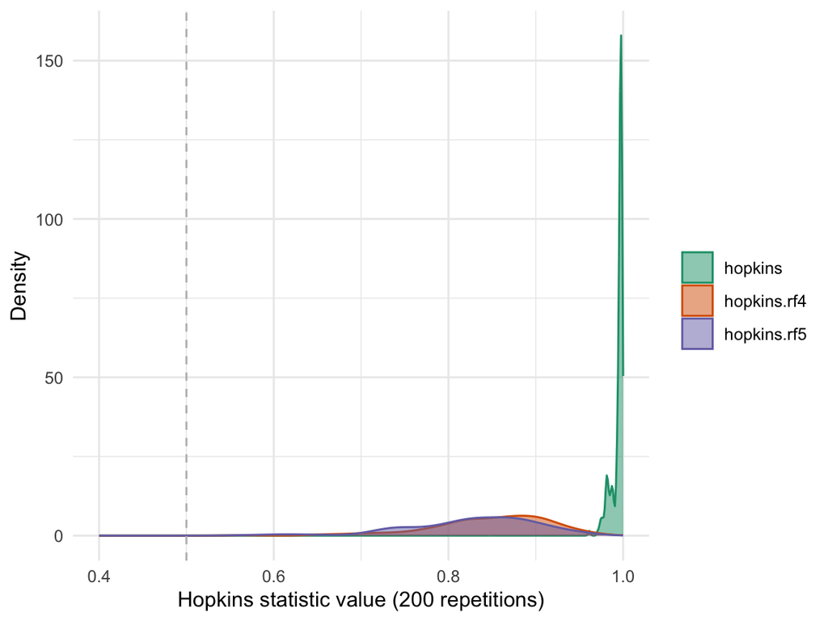

```r
tmp = iris[, 1:4] %>% scale()
vals = cache_rds({
    sapply(1:200, function(s) {
        c(Hopkins.rf4(iris[,1:4], k=1, m=30, seed=s),
          Hopkins.rf5(iris[,1:4], k=1, m=30, seed=s),
          hopkins::hopkins(tmp, m=30, k=1))
    })
}, rerun=F, clean=T)
vals = setNames(data.frame(t(vals)), c('hopkins.rf4', 'hopkins.rf5', 'hopkins')) %>%
    pivot_longer(everything())
ggplot(vals) +
    geom_density(aes(x=value, color=name, fill=name), alpha=0.5) +
    scale_color_brewer(name="", palette='Dark2') +
    scale_fill_brewer(name="", palette='Dark2') +
    ylab('Density') +
    scale_x_continuous(name="Hopkins statistic value (200 repetitions)", limits=c(0.4, 1)) +
    geom_vline(xintercept=0.5, linetype='dashed', color="grey") +
    theme_minimal()
```

Observations:

- The values with this new formula are closer to the values produced by the `hopkins` package, but are still not the same distribution.
- hopkins.rf5 samples data from the hypercube (random uniform for continuous; equal probability for categorical)
  - it does not yield significantly different results from permutation via hopkins.rf4

## 5.2 Iris test with random features

We expect the value to decrease as the number of random features are added to the data set.

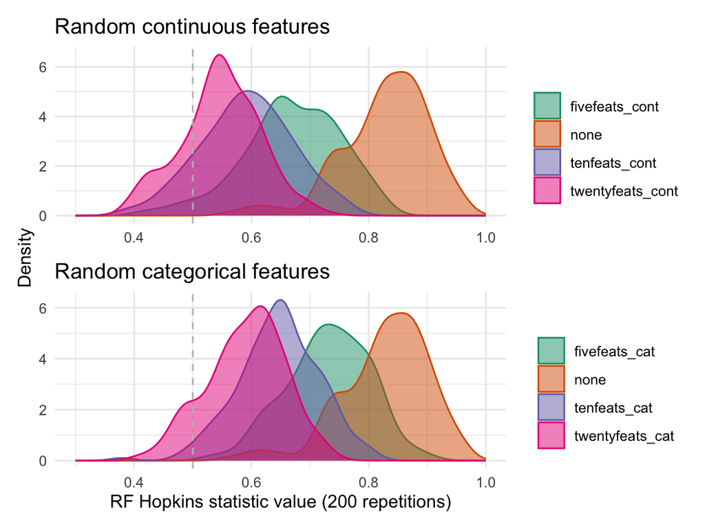

```r
add_randfeats = function(x, n, type=c('cont', 'cat'), num.cat=3) {
    type = match.arg(type)
    if(type == 'cont') {
        tmp = do.call('data.frame',
                      lapply(1:n, function(.x) runif(n=nrow(x))))
        colnames(tmp) = paste0('randcontinuous_', 1:n)
        return(cbind(x, tmp))
    } else if(type == 'cat') {
        tmp = do.call('data.frame',
                      lapply(1:n, function(.x) factor(sample(1:num.cat, size=nrow(x), replace=T))))
        colnames(tmp) = paste0('randcategorical_', 1:n)
        return(cbind(x, tmp))
    } else {
        return(x)
    }
}
vals = cache_rds({
    parallel::mclapply(1:200, function(s) {
        if(s %% 20 == 0) ic(s)
        set.seed(s)
        data.frame(
          none=Hopkins.rf5(iris[,1:4], k=1, m=30, seed=s),
          fivefeats_cont=Hopkins.rf5(add_randfeats(iris[,1:4], 5), k=1, m=30, seed=s),
          tenfeats_cont=Hopkins.rf5(add_randfeats(iris[,1:4], 10), k=1, m=30, seed=s),
          twentyfeats_cont=Hopkins.rf5(add_randfeats(iris[,1:4], 20), k=1, m=30, seed=s),
          fivefeats_cat=Hopkins.rf5(add_randfeats(iris[,1:4], 5, type='cat'), k=1, m=30, seed=s),
          tenfeats_cat=Hopkins.rf5(add_randfeats(iris[,1:4], 10, type='cat'), k=1, m=30, seed=s),
          twentyfeats_cat=Hopkins.rf5(add_randfeats(iris[,1:4], 20, type='cat'), k=1, m=30, seed=s)
         )
    }, mc.cores=4)
}, rerun=F, clean=T)
vals = bind_rows(vals) %>%
    pivot_longer(everything())
p1 = ggplot(vals %>% filter(name == 'none' | grepl('cont', name))) +
    geom_density(aes(x=value, color=name, fill=name), alpha=0.5) +
    scale_color_brewer(name="", palette='Dark2') +
    scale_fill_brewer(name="", palette='Dark2') +
    ylab('Density') +
    scale_x_continuous(name="RF Hopkins statistic value (200 repetitions)", limits=c(0.3, 1)) +
    geom_vline(xintercept=0.5, linetype='dashed', color="grey") +
    ggtitle("Random continuous features") +
    theme_minimal()
p2 = ggplot(vals %>% filter(name == 'none' | grepl('cat', name))) +
    geom_density(aes(x=value, color=name, fill=name), alpha=0.5) +
    scale_color_brewer(name="", palette='Dark2') +
    scale_fill_brewer(name="", palette='Dark2') +
    ylab('Density') +
    scale_x_continuous(name="RF Hopkins statistic value (200 repetitions)", limits=c(0.3, 1)) +
    geom_vline(xintercept=0.5, linetype='dashed', color="grey") +
    ggtitle("Random categorical features") +
    theme_minimal()
p1 / p2 + plot_layout(axis_titles = 'collect')
```